# Polity Size and Local Government Performance: Evidence from India Narasimhan and Weaver (2024)

MY457 | WT 2026

Author

61578

Published

May 31, 2026

# 1. Introduction and Research Design

How large should a local government be? This question has been around for a long time, but until recently, it was difficult to answer with confidence. The size of a political unit is rarely chosen randomly. Larger and smaller jurisdictions often differ in many ways that also influence how well they are governed. Because of this, a naïve comparison between big and small governments doesn’t reveal the true causal relation.

Narasimhan and Weaver (2024) address this issue by using an administrative rule in Uttar Pradesh, India. The *Gram Panchayat* (GP), village council, is the lowest level of elected government and usually includes several villages under one council. According to the rule, any village with a population over 1,000 in the most recent census should become its own GP. Villages with fewer than 1,000 people remain grouped with neighboring villages in a larger GP. This leads to a clear divide: two villages with nearly the same population, such as 995 and 1,005 people, can end up in GPs of very different sizes simply because they fall on opposite sides of this cutoff.

The authors use a **regression discontinuity design (RDD)**. This seems like selection on observables (SOO). If treatment only depends on population size, why not just control for population? But the common support assumption will not be fulfilled. For any specific population size, we only see either treated or untreated villages, not both. This means villages from the cutoff have almost absolute certainty that they will be either treated or untreated. However, RDD solves this by using the ‘as-if random’ variation right at the cutoff, which lets us find the effect exactly at the threshold instead of trying to control for it.

The **running variable** in this study is the village population recorded in the census before delimitation. The **cutoff** population is set at 1,000. The **treatment** is whether a village is assigned to a smaller GP. The authors use this design twice, applying it to two separate rounds of boundary changes: once in 1995 (using the 1991 census) and again in 2015 (using the 2011 census). Having two delimitation episodes, twenty years apart, is a strength of this study because it is almost like repeating the natural experiment.

I would like to highlight one design choice that shapes everything that follows and is central to an additional analysis I performed. When a village crosses the 1,000 mark, it does not just change one thing. Instead, several things change together: the village moves into a GP with a smaller population, but also one that is more compact geographically and often more similar in caste makeup. The authors make it clear that they are not trying to isolate the effect of population size alone. Since you cannot reduce a GP’s population keeping these other things constant, they estimate the **sharp discontinuity**, meaning the effect of crossing the threshold with all these changes together. They state clearly that they “focus on estimating the sharp discontinuity rather than instrumenting for any one of these treatments in a fuzzy RD design.” I will come back to this point.

The data bring together the Indian Population Census and a wide range of administrative and survey sources, including information on schools, roads, sanitation, welfare program participation, the NREGS workfare scheme, and local election records. Villages are matched across these sources using census identifiers, with match rates above 95 percent. Importantly, the authors show that match quality does not change at the cutoff, so selective missing data will not confound the treatment effect estimate.

Figure 1 and 2 present the first stage graphically. The GP population falls sharply at the cutoff in both delimitation episodes.

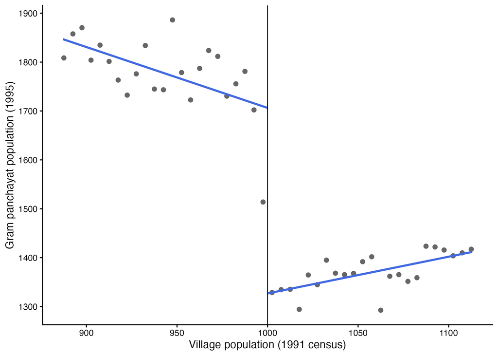

Figure 1: First stage: village and GP population at the 1,000 cutoff (1991 census)

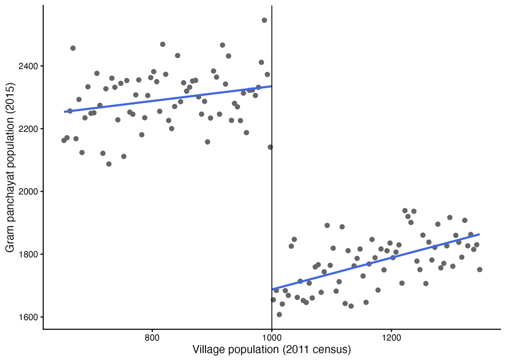

Figure 2: First stage: village and GP population at the 1,000 cutoff (2011 census)

# 2. Identification Strategy and Assumptions

An RDD depends on two main assumptions, and the strength of the paper relies almost completely on these.

**Assumption 1: No manipulation of the running variable.** For this design to be valid, villages should not be able to move themselves across the 1,000 line. If village leaders could adjust their reported population to just above the threshold to get their own GP, then villages just above and just below the line might differ in ambition, political connections, or administrative skills. This is exactly the kind of confounding the design is meant to avoid. In DAG terms, manipulation would open the back-door path that continuity (Assumption 2) is supposed to close.

Let us check how credible is the claim of no manipulation here. I find this claim somewhat credible, mainly because the census was conducted four years before anyone knew it would be used for delimitation. It seems unlikely that people can manipulate a rule they do not know about. The authors support this with a density test (Cattaneo, Jansson, and Ma 2018) which checks if villages disproportionately cluster just above the cutoff. They report p-values of 0.44 for the 1991 distribution and 0.35 for the 2011 distribution, showing no evidence of manipulation. I repeated this density test and found the same result, shown in Figure 3 and 4.

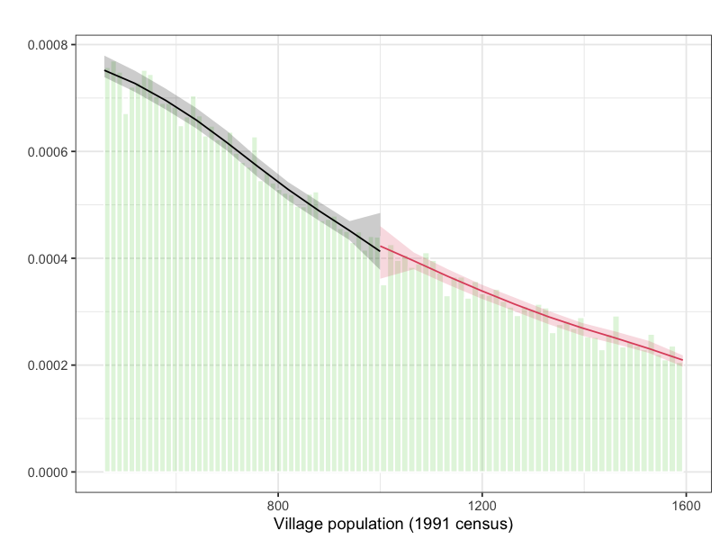

Figure 3: Manipulation density test at the 1,000 cutoff (1991 census)

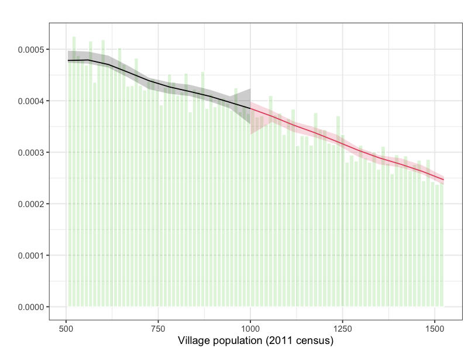

Figure 4: Manipulation density test at the 1,000 cutoff (2011 census)

However, I did notice something worth mentioning that the paper does not discuss. When I looked at the running variable near the cutoff, I found that the population value of exactly 1,000 has unusually few villages, with only 10 in the 1991 data. This is much lower than the surrounding values, which on average range between 40-50 on every number. This is actually the opposite of manipulation - instead of seeing more villages just above the cutoff, there is a small dip right at it. Though, this does not threaten the research design.

**Assumption 2: Continuity of all other covariates at the cutoff.** The continuity framework requires that average potential outcomes, meaning what villages would look like with and without treatment, change smoothly through the cutoff. In other words, *nothing except GP assignment* should change suddenly at 1,000. For example, if another government program also used a 1,000-person threshold, then villages above that line would get two treatments at once, making it impossible to attribute outcome differences to GP size alone. This assumption is the most open to scrutiny, and the authors test it directly. Columns 2 to 7 of Table 1 check whether baseline village characteristics like schools, roads, electricity, caste, and literacy shares change suddenly at the cutoff. They do not.

The main risk to continuity comes from another program using the same cutoff. To address this, the authors conduct several placebo tests. They show there is no jump in GP population at 1,000 in other Indian states that do not use the rule. They also find no outcome discontinuities in Uttar Pradesh districts that ignored the rule, and they check the cutoff in the 2001 census, which was not used for delimitation. Taken together, I find these tests convincing. While no single test is conclusive, it is difficult to explain the observed discontinuity in population change except by the 1000-threshold rule, since it only appears where and when the rule was applied. My own balance reproductions appear in the following figures.

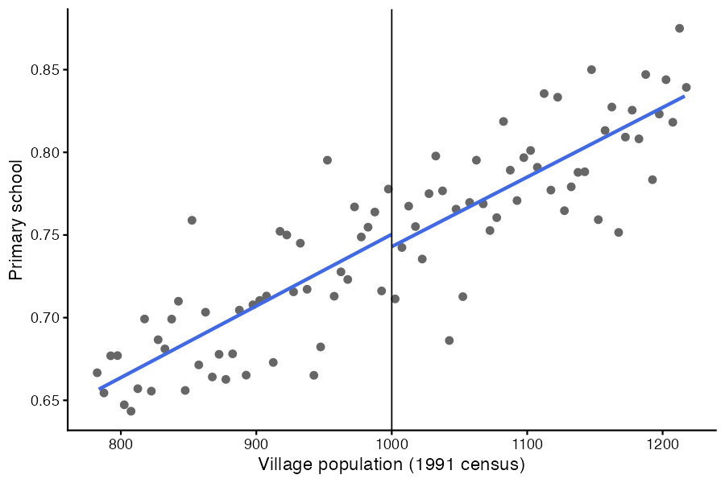

Figure 5: Balance - Primary School (1991)

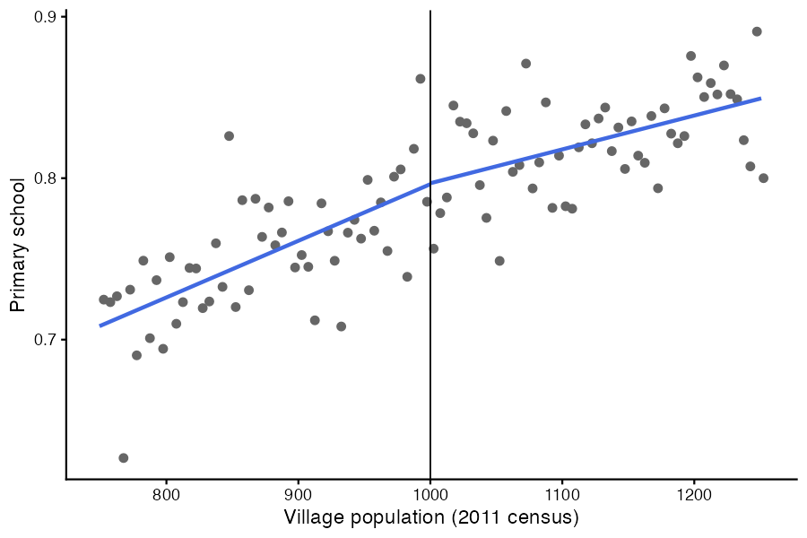

Figure 6: Balance - Primary School (2011)

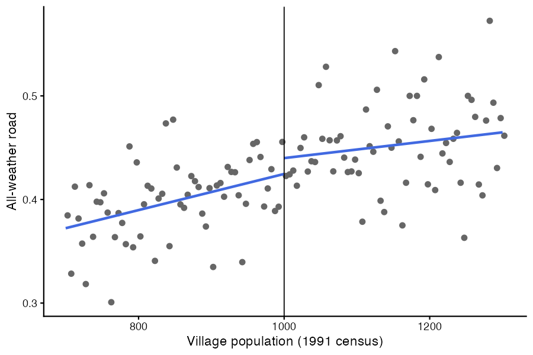

Figure 7: Balance - All-season Road (1991)

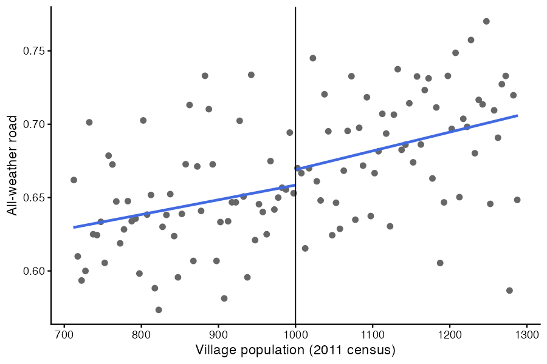

Figure 8: Balance - All-season Road (2011)

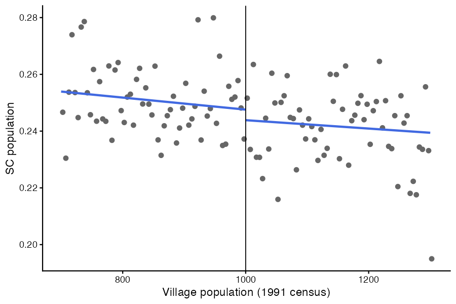

Figure 9: Balance - SC proportion (1991)

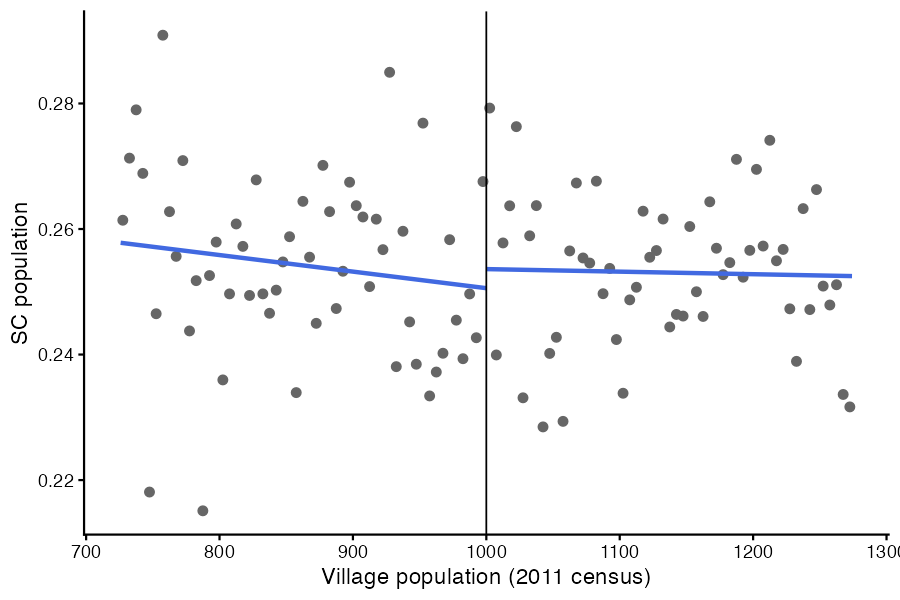

Figure 10: Balance - SC proportion (2011)

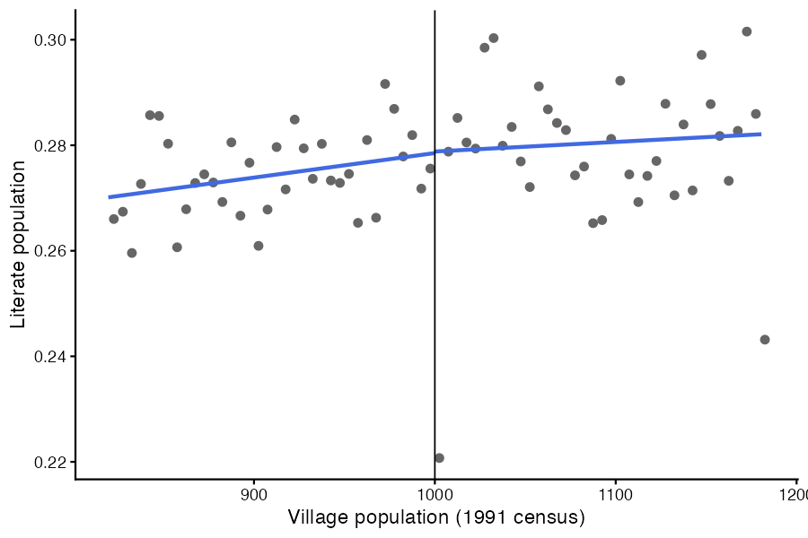

Figure 11: Balance - Literate proportion (1991)

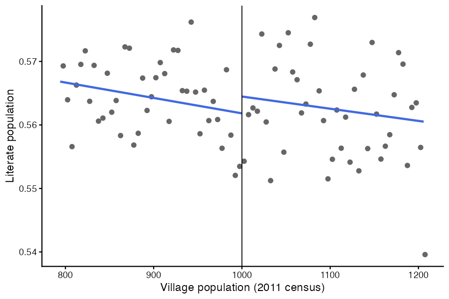

Figure 12: Balance - Literate proportion (2011)

I am a bit more cautious about spillovers, which relate to the **Stable Unit Treatment Value Assumption (SUTVA)** we discussed in class. When one village becomes its own GP, the villages left behind are also in a smaller GP. This means a village’s outcome might depend on whether its neighbor was treated, which would violate SUTVA if the neighbor was untreated. The authors recognize this issue and address it in the appendix by using a block-level instrument for the number of GPs. They find little evidence of negative spillovers. However, they also acknowledge that the spillover test is weak in the 2015 period, so the results for that period are not as precise.

Overall, the identifying assumptions looks good. The manipulation assumption holds true because of the timing, and the continuity assumption passes a thorough set of placebo tests.

# 3. Replication of the Main Results

I reproduced the paper’s three main tables in R, using the authors’ Stata replication files as a starting point. I consider Table 1 (first stage and balance), Table 2 (effects on village amenities), and Table 3 (effects on welfare programs and NREGS) to be the main empirical results, since they support the paper’s main claim that smaller polities provide more public goods. For all estimates, I used the `rdrobust` package with a triangular kernel, a linear polynomial, and an MSE-optimal bandwidth, just as in the original paper.

**The First Stage:** Before we look at any outcomes, the design needs the rule to have a real effect. Table 1 shows that crossing the 1,000 threshold reduces the population of a village’s GP by -362 people in the 1995 delimitation episode and -649 in the 2015 episode. This is a clear and significant discontinuity. Villages just above the cutoff really do end up in much smaller administrative units. Figure 1 and 2 show this jump visually.

Table 1: Reproduction of Table 1: First stage and balance of baseline village characteristics.

Panel A: 1991 census / 1995 delimitation

| Variable | Estimate | SE | P-value | Dep Mean | Bandwidth | Eff. Obs |
| --- | --- | --- | --- | --- | --- | --- |
| GP population | -362.037*** | (27.623) | [0.000] | 1776.442 | 115 | 8899 |
| Primary school (=1) | -0.008 | (0.014) | [0.572] | 0.699 | 227 | 18313 |
| Middle school (=1) | 0.009 | (0.007) | [0.383] | 0.063 | 370 | 30870 |
| Paved road (=1) | 0.019 | (0.014) | [0.147] | 0.399 | 287 | 23507 |
| Electricity (=1) | 0.008 | (0.010) | [0.396] | 0.178 | 359 | 29696 |
| SC fraction | -0.007 | (0.005) | [0.208] | 0.251 | 302 | 24743 |
| Literate fraction | 0.001 | (0.004) | [0.988] | 0.274 | 184 | 14829 |

Panel B: 2011 census / 2015 delimitation

| Variable | Estimate | SE | P-value | Dep Mean | Bandwidth | Eff. Obs |
| --- | --- | --- | --- | --- | --- | --- |
| GP population | -649.014*** | (28.317) | [0.000] | 2294.180 | 353 | 28277 |
| Primary school (=1) | 0.003 | (0.012) | [0.778] | 0.752 | 251 | 20216 |
| Middle school (=1) | -0.003 | (0.013) | [0.638] | 0.284 | 327 | 26196 |
| Paved road (=1) | 0.007 | (0.014) | [0.688] | 0.644 | 292 | 23333 |
| Electricity (=1) | 0.022 | (0.015) | [0.149] | 0.572 | 278 | 22105 |
| SC fraction | 0.003 | (0.006) | [0.625] | 0.254 | 268 | 21510 |
| Literate fraction | 0.004 | (0.003) | [0.211] | 0.564 | 208 | 16769 |

**Balance:** The remaining columns of Table 1 are central to the credibility of the design. They check whether pre-treatment village characteristics such as schools, roads, electricity, caste, and literacy shares differ across the cutoff. They do not. Each estimate is small and statistically insignificant, and my reproduced balance plots (Figure 5-12) show flat lines at the threshold. If villages just above 1,000 had better schools before delimitation, the design would not work. The fact that they do not is the key evidence for the continuity assumption.

**The Effects:** Table 2 and Table 3 show the main findings, and my results are consistent. Villages in smaller GPs have better outcomes in many areas: more household toilets and closed drains, better education, and in 2015, higher participation in welfare programs and NREGS workfare. My point estimates and standard errors closely match the published numbers, accurate to two or three decimal places.

Table 2: Reproduction of Table 2: Effects on village amenities.

Panel A: Educational outcomes

| Variable | Estimate | SE | P-value | Dep Mean | BW | Eff. N |
| --- | --- | --- | --- | --- | --- | --- |
| Education index | 0.086*** | (0.021) | [0.000] | -0.115 | 216 | 17063 |
| Primary school (2001) | 0.027* | (0.012) | [0.064] | 0.834 | 194 | 15272 |
| Middle school (2001) | 0.017* | (0.009) | [0.091] | 0.120 | 386 | 31579 |
| Primary school (2011) | 0.019 | (0.012) | [0.109] | 0.845 | 217 | 17215 |
| Middle school (2011) | 0.047*** | (0.015) | [0.003] | 0.426 | 288 | 23093 |
| Above primary educ. (2012) | 13.539* | (7.998) | [0.070] | 572.195 | 366 | 28766 |
| Education score (2019) | 1.672*** | (0.431) | [0.000] | 31.211 | 401 | 32481 |

Panel B: Village-level infrastructure

| Variable | Estimate | SE | P-value | Dep Mean | BW | Eff. N |
| --- | --- | --- | --- | --- | --- | --- |
| Village amenities index | 0.052** | (0.019) | [0.013] | 0.262 | 336 | 27237 |
| Paved road (2001) | 0.031** | (0.011) | [0.024] | 0.560 | 448 | 36995 |
| Tap water (2001) | 0.016 | (0.014) | [0.253] | 0.392 | 315 | 24668 |
| Paved road (2011) | -0.007 | (0.011) | [0.684] | 0.686 | 406 | 33144 |
| Fair price shop (2011) | 0.027* | (0.012) | [0.056] | 0.770 | 228 | 18128 |
| Community centre (2011) | 0.020 | (0.013) | [0.144] | 0.325 | 338 | 27327 |

Panel C: Household-level infrastructure

| Variable | Estimate | SE | P-value | Dep Mean | BW | Eff. N |
| --- | --- | --- | --- | --- | --- | --- |
| HH amenities index | 0.092*** | (0.023) | [0.000] | -0.046 | 248 | 19682 |
| House quality index | 0.039** | (0.016) | [0.040] | 0.087 | 299 | 23932 |
| Piped water | 0.044 | (0.725) | [0.970] | 20.296 | 369 | 30092 |
| Households with toilet | 3.249*** | (0.643) | [0.000] | 17.822 | 223 | 17696 |
| Open defecation | -3.334*** | (0.667) | [0.000] | 81.060 | 223 | 17696 |
| Closed drains | 1.217** | (0.460) | [0.017] | 6.975 | 264 | 21007 |

**Interpreting the Magnitudes:** There are two important cautions to keep in mind, as they affect how much we can rely on these results. First, the RDD estimate is a local effect, showing the impact of GP size only for villages right at the 1,000-person cutoff. Since a village of 1,000 people is quite small, we cannot assume the same effect would happen if a city of 50,000 were divided. The paper’s conclusions apply only to villages near this threshold, so treating them as a general rule for all polity sizes would be a stretch. Second, the treatment involves several changes at once. When a village crosses the cutoff, its GP population gets smaller, but it also becomes more geographically concentrated and more socially homogeneous. So, when Table 2 shows more toilets above the cutoff, we cannot say for sure that this is due to population size rather than the geographic or social changes that come with it. The authors are careful to point this out. The estimate tells us what happens when a village crosses the threshold, not what happens because of polity size alone. My additional analysis in Section 4 focuses on this issue.

Table 3: Reproduction of Table 3: Effects on welfare programmes and NREGS.

Panel A: Individual-level programs

| Variable | Estimate | SE | P-value | Dep Mean | BW | Eff. N |
| --- | --- | --- | --- | --- | --- | --- |
| Programs index | 0.087*** | (0.033) | [0.008] | 0.096 | 160 | 12812 |
| BPL card | 5.087* | (2.445) | [0.058] | 93.299 | 309 | 24643 |
| Health insurance | 2.227** | (1.078) | [0.047] | 22.361 | 265 | 21245 |
| Pension | -1.339 | (1.085) | [0.333] | 35.342 | 278 | 22180 |
| Saubhagya | 2.523* | (1.385) | [0.095] | 41.952 | 384 | 30556 |
| LPG | 5.710** | (2.475) | [0.018] | 96.193 | 205 | 16413 |
| Housing benefits | 5.595*** | (2.201) | [0.010] | 41.618 | 200 | 16079 |
| PMMVY | 0.100 | (0.135) | [0.647] | 2.571 | 361 | 28669 |
| Jan Dhan | 4.992** | (2.052) | [0.011] | 69.311 | 212 | 17079 |

Panel B: NREGS program implementation

| Variable | Estimate | SE | P-value | Dep Mean | BW | Eff. N |
| --- | --- | --- | --- | --- | --- | --- |
| NREGS index | 0.162*** | (0.026) | [0.000] | 0.079 | 335 | 117879 |
| Work demand | 0.011*** | (0.001) | [0.000] | 0.078 | 368 | 130048 |
| Days worked | 0.310*** | (0.051) | [0.000] | 2.034 | 325 | 114869 |
| Labor expenditure | 63.667*** | (9.716) | [0.000] | 393.193 | 319 | 112634 |
| Material expenditure | 22.844*** | (5.555) | [0.001] | 147.882 | 306 | 108077 |
| Total projects | 0.006*** | (0.002) | [0.003] | 0.086 | 320 | 112634 |

**Reproduction Discrepancies:** To match the numbers, I had to make a specific choice. `rdrobust` function provides conventional, bias-corrected, and robust estimates. At first, my estimates and standard errors did not align with the original values as I was extracting the robust estimates. When I realized that the authors used the conventional estimates and conventional clustered standard errors, I switched to those, and the numbers matched across all three tables. After this change, only very small differences in bandwidths and effective observations remained. These minor differences come from small cross-platform variations between the R and Stata versions of `rdrobust` and do not affect any signs or conclusions.

In summary, the paper’s results are reproducible. The first stage is robust, balance is maintained, and the effects are broad and consistent across two natural experiments. Any remaining differences are minor software artifacts. The main conclusion that smaller local governments perform better is confirmed by independent recomputation.

## 4. A Fuzzy RD: Recovering the Effect of Being a Solo *Gram Panchayat*

My further analysis focuses on the area where the authors intentionally do not go further. The authors estimate the sharp discontinuity, which is the effect of crossing the 1,000 mark, and choose not to run a fuzzy RD since the treatment is bundled. This is a reasonable decision. However, it means that a key measure for policymakers is left out. The sharp estimate tells us what happens when a village crosses the threshold of 1,000, but not what happens when a village is actually given its own GP. These are different because the rule is not always followed (compliance issue): some villages above 1,000 do not become solo GPs (never-takers), and some below 1,000 do not stay merged (always-takers). As a result, the sharp RD underestimates the effect of the policy decision to grant a village its own council, since it includes never-takers villages where crossing the line made no difference.

I estimate a **fuzzy regression discontinuity (RD)** design. This approach uses a local instrumental-variables method: I use an indicator for crossing the 1,000 population cutoff as an instrument for whether a village is a solo (single-village) GP, within the MSE-optimal bandwidth. The first stage checks if crossing the cutoff actually leads to solo GP status, and the second stage adjusts the reduced-form effect by the compliance rate. This gives a **local average treatment effect (LATE)**, which measures the effect of solo-GP status for *compliers* - the villages whose solo status is determined by the rule. In practice, LATE is the sharp (intent-to-treat) effect divided by the first stage. While, the sharp estimate is the local intent-to-treat effect of crossing the threshold, which shows the effect of the encouragement rather than the treatment itself. I chose a binary solo-GP treatment instead of using continuous GP population because the real policy question is whether a village should get its own council. While a per-person estimate is tidy and informative, it is not useful for practical decisions.

I run this analysis on a few outcomes that show the clearest sharp-RD effects, using the correct delimitation episode for each. For the 1995 episode, I focus on village amenities like paved roads, tap water, toilets, and closed drains. For the 2015 episode, I only look at NREGS workfare outcomes. Table 4 reports the results.

Table 4: Fuzzy RD (LATE) estimates of solo-GP status effect

Block 1: 1995 delimitation (amenities provision)

| Variable | Estimate | SE | P-value | Dep Mean | BW | Eff. N |
| --- | --- | --- | --- | --- | --- | --- |
| Paved road (2001) | 0.099* | (0.054) | [0.076] | 0.586 | 188 | 14867 |
| Tap water (2001) | 0.073 | (0.056) | [0.189] | 0.394 | 184 | 14018 |
| Toilet (%) | 10.462*** | (2.525) | [0.000] | 18.019 | 146 | 11517 |
| Closed drains (%) | 3.769** | (1.763) | [0.031] | 7.173 | 178 | 13969 |

Block 2: 2015 delimitation (NREGS implementation)

| Variable | Estimate | SE | P-value | Dep Mean | BW | Eff. N |
| --- | --- | --- | --- | --- | --- | --- |
| NREGS index | 0.454*** | (0.057) | [0.000] | 0.102 | 529 | 185923 |
| Work demand | 0.032*** | (0.004) | [0.000] | 0.077 | 255 | 90463 |
| Days worked | 0.859*** | (0.189) | [0.000] | 2.019 | 195 | 69061 |
| Labor expenditure | 174.377*** | (27.018) | [0.000] | 393.631 | 304 | 107077 |
| Material expenditure | 61.928*** | (19.308) | [0.004] | 146.085 | 204 | 72612 |
| Total projects | 0.016*** | (0.006) | [0.007] | 0.086 | 195 | 69381 |

What does this add? There are three main points, and I am clear about the limits of each. First, it puts the paper’s findings into terms that matter to policymakers: instead of saying “crossing a line does X,” it shows that “creating a solo GP does roughly 3X.” Second, it measures the size of the effect. The sharp RD reduces the treatment effect by averaging over people who do not comply, and the fuzzy estimate shows how large is the actual effect. Third, since the authors chose not to do this themselves, I believe, this is a real extension of their work.

# 5. Conclusion

# Code Appendix

```r
knitr::opts_chunk$set(echo = FALSE, warning = FALSE, message = FALSE, linewidth = 60)
options(scipen = 999)

# ── Libraries ────────────────────────────────────────────────────────────────
library(tidyverse)
library(haven)
library(rdrobust)
library(rddensity)
library(kableExtra)

# ==============================================================================
# MY457: Reappraisal Summative Assignment
# "Polity Size and Local Government Performance: Evidence from India"
# Narasimhan & Weaver (2024), American Economic Review, 114(11): 3385-3426
# ==============================================================================

root <- "."
source("code/MY457_61578_analysis_script.R")

bunch_1000 <- sum(vd$pc91_pca_tot_p == 1000, na.rm = TRUE)

knitr::include_graphics(
  file.path(main_fig, "figure1a.png"))
knitr::include_graphics(
  file.path(main_fig, "figure1b.png"))
knitr::include_graphics(
  file.path(app_fig, "manipulationtest_1991.png"))
knitr::include_graphics(
  file.path(app_fig, "manipulationtest_2011.png"))
knitr::include_graphics(
  file.path(app_fig, "any_primary91_balance.png"))
knitr::include_graphics(
  file.path(app_fig, "any_primary11_balance.png"))
knitr::include_graphics(
  file.path(app_fig, "pc91_vd_tar_road_balance.png"))
knitr::include_graphics(
  file.path(app_fig, "pc11_vd_tar_road_balance.png"))
knitr::include_graphics(
  file.path(app_fig, "sc_prop91_balance.png"))
knitr::include_graphics(
  file.path(app_fig, "sc_prop11_balance.png"))
knitr::include_graphics(
  file.path(app_fig, "lit_prop91_balance.png"))
knitr::include_graphics(
  file.path(app_fig, "lit_prop11_balance.png"))
kable(tab1A, caption = "Panel A: 1991 census / 1995 delimitation") |>
  kable_styling(full_width = FALSE)

kable(tab1B, caption = "Panel B: 2011 census / 2015 delimitation") |>
  kable_styling(full_width = FALSE)
kable(tab2A, caption = "Panel A: Educational outcomes") |>
  kable_styling(full_width = FALSE)

kable(tab2B, caption = "Panel B: Village-level infrastructure") |>
  kable_styling(full_width = FALSE)

kable(tab2C, caption = "Panel C: Household-level infrastructure") |>
  kable_styling(full_width = FALSE)
kable(tab3A, caption = "Panel A: Individual-level programs") |>
  kable_styling(full_width = FALSE)

kable(tab3B, caption = "Panel B: NREGS program implementation") |>
  kable_styling(full_width = FALSE)
kable(tab_fuzzy_95, caption = "Block 1: 1995 delimitation (amenities provision)") |>
  kable_styling(full_width = FALSE)

kable(tab_fuzzy_15, caption = "Block 2: 2015 delimitation (NREGS implementation)") |>
  kable_styling(full_width = FALSE)
```